# ANLT_232_Assignment_2

A Critique of HW #2 as HW #3: In-Depth Visualization and Analysis of Fuel Consumption

**Intro to Data Visualization**  
**ANLT 232**  
**Febuary 4th, 2018**  
**Austin Jarvis, Joe Jung, Brendon Ngo & Max Riching**

By: Ali Taheri

## *Importing Packages*

```python
import warnings
warnings.filterwarnings('ignore') #change to 'default' to reset, 'ignore' to remove futurewarning/deprecated code
import pandas.tseries as tseries #using pandas.tseries instead of datetools
import pandas as pd
import numpy as np
import random
import matplotlib.pyplot as plt
%matplotlib inline
from matplotlib import rcParams
import seaborn as sns
import statsmodels.api as sm

sns.set_style("darkgrid")
sns.set_context("poster")

rcParams['figure.figsize'] = (12.0, 8.0)
```

## *Background*

Saving money has long been considered an important virtue. While there are some who consider saving an easy task, there are times when it is difficult to make the proper financial decisions, such as when one buys a car for the first time. Even with ride sharing and public transportation becoming popular in metropolitan cities the large majority of America still own cars, making such purchases inevitable. After all, the automotive industry is one of the most important revenue creating sectors in America.

Consumers buy cars based on a variety of factors including style, gas mileage, safety or emissions to name a few. Many trends come and go in the industry but it seems electric cars are a trend that will definitely be sticking around. The advancements in battery technology has allowed for electric cars to have similar range to vehicles powered by combustions engines while not requiring the trip to the gas station and producing zero emisions. Even with the significant advancements, it is estimated that one in six new cars sold in 2025 will be electric. This change to the industry leads to more options when it comes time to buy.

There are many factors to consider when purchasing a car other than initial price, such as fuel costs, miles per gallon (MPG), fuel type, average lifespan, brand, and model. These factors tend to confuse initial consumers, and many simply pick the car that is the most visually appealing, or the least expensive. In order to assist consumers in making better choices when selecting vehicles, we have decided to analyze a few important features to consider before a purchase.

We propose that Japanese manufacturers place a greater significance on the overall monetary cost-to-savings ratio from fuel efficiency of cars than American manufacturers. More specifically, this claim will focus on the difference in fuel emissions, fuel economy and comparative monetary savings between major American and Japanese car manufacturers.

If we compare different countries of the world, definitely US would be one of developed countries that a lot of people are using personal vehicles. Beside a vehicle for every member of family, some persons have two or even more cars. Based on this fact, selection of a vehicle with suitable purchase price at first and then optimized cost for fuel, oil and maintenance is very important for a lot of US families. Analysis of mentioned parameters would help individuals and families to purchase an optimum vehicle for their self. It is obvious that a lot of Americans are in doubt about this issue. At first, it is required to mention that there are some trade-offs between parameters of interest. For example, people can purchase a price with higher price at first and then their fuel cost could be very low. Some great examples are hybrid and full electric cars same to Tesla which their fuel cost is very low. These types of analysis would be very useful and I think a lot of vehicle guys would love them.

## *Features Defined*

We have selected the following features of the dataset to focus on:

- **co2TailpipeGpm** - tailpipe CO2 in grams/mile for fuelType1
- **comb08** - combined MPG for fuelType1
- **cylinders** - engine cylinders
- **displ** - engine displacement in liters
- **fuelCost08** - annual fuel cost for fuelType1
- **model** - model name (carline)
- **make** - manufacturer (division)
- **phevComb** - EPA composite gasoline-electricity combined city-highway MPGe for plug-in hybrid vehicles
- **youSaveSpend** - you save/spend over 5 years compared to an average car ($). Savings are positive; a greater amount spent yields a negative number. For dual fuel vehicles, this is the cost savings for gasoline
- **year** - model year

*Additional note:*

Since there are various fuel types included within the dataset, such as liquefied petroleum gas, compressed natural gas, ethanol 85%, hydrogen gas, and others, the charts containing the MPG data also include the MPGe of electric vehicles (EVs), since electricity is also a fuel that individuals pay for.

It seems that some features need to be described more. Especially normal audiences could not understand some features with these short definitions. For example, definition of youSaveSpend could be as following:  
**youSaveSpend**: The label shows the estimated fuel cost over a five-year period for the vehicle compared to the average new vehicle. If the vehicle would save the consumer money compared to the average vehicle, the label would state, “You save USD x,xxx in fuel costs over 5 years compared to the average new vehicle.” If the vehicle would be more expensive to operate than the average vehicle, the label would state, “You spend USD x,xxx more in fuel costs over 5 years compared to the average new vehicle.” These estimates are based on driving 15,000 miles per year, for five years, and the projected fuel price for the year, which changes annually, and is referenced in the fine print.  
These descriptions are very important for some people that do not have background information and understanding of analysis would not be possible without a suitable perception of these attributes. </font>

## *Data Preparation*

```python
vehicles_df = pd.read_csv('http://www.fueleconomy.gov/feg/epadata/vehicles.csv.zip',low_memory=False)
print("Number of rows & columns:",vehicles_df.shape)

vehicles_df = vehicles_df[["year", "comb08", "youSaveSpend", "fuelCost08", "cylinders", "displ", "make","phevComb", "co2TailpipeGpm"]]

# creating a new column to group by Japanese and American based major manufacturers
vehicles_df.ix[vehicles_df['make'].isin(['Honda','Suzuki','Subaru','Toyota','Mazda','Mitsubishi','Nissan']),'region'] = "Japan"
vehicles_df.ix[vehicles_df['make'].isin(['Pontiac','Plymouth','Mercury','Buick','Chrysler','Ford','Chevrolet','Jeep','Cadillac','Dodge','GMC']),'region'] = "United States"

vehicles_df.head(5)
```

```
Number of rows & columns: (39530, 83)
```

|  | year | comb08 | youSaveSpend | fuelCost08 | cylinders | displ | make | phevComb | co2TailpipeGpm | region |
| --- | --- | --- | --- | --- | --- | --- | --- | --- | --- | --- |
| 0 | 1985 | 21 | -2000 | 1850 | 4.0 | 2.0 | Alfa Romeo | 0 | 423.190476 | NaN |
| 1 | 1985 | 11 | -10500 | 3550 | 12.0 | 4.9 | Ferrari | 0 | 807.909091 | NaN |
| 2 | 1985 | 27 | 0 | 1450 | 4.0 | 2.2 | Dodge | 0 | 329.148148 | United States |
| 3 | 1985 | 11 | -10500 | 3550 | 8.0 | 5.2 | Dodge | 0 | 807.909091 | United States |
| 4 | 1993 | 19 | -4750 | 2400 | 4.0 | 2.2 | Subaru | 0 | 467.736842 | Japan |

To focus on factors that would be useful for consumers nine variables were selected. These variables allow for the analysis of the fuel efficiency, cost and emissions over time. Grouping both American and Japanese made vehicles into regions allows for a more broad generalization when trying to determine a car to purchase.

Selected features could be satisfactory normal audiences, but it could be better to consider some important parameters same to "Drive" and number of speeds for automatic transmission. Additionally, name of some parameters is very weird, and it could be better if change them to familiar names for audiences. Some of them are:  
** comb08: ** MPG or MilePerGallon  
** fuelCost08 :** YearlyGazCost  
** phevComb:** HybridMPG  
Usage of original attribute names would make hard understanding of analysis for all people, because they see strange names on axes of visualizations and perception of graph would be hard for them. </font>

## *Exploratory Analysis*

In order to explore the data, we wanted to determine the range of unique values present in our dataset, so the following function provides a brief insight into the values within the dataset.

```python
def rstr(df): return df.shape, df.apply(lambda x: [x.unique()])
print(rstr(vehicles_df))
```

```
((39530, 10), year              [[1985, 1993, 1994, 1995, 1996, 1997, 1998, 19...
comb08            [[21, 11, 27, 19, 22, 25, 24, 26, 13, 23, 20, ...
youSaveSpend      [[-2000, -10500, 0, -4750, -1750, -500, -1000,...
fuelCost08        [[1850, 3550, 1450, 2400, 1800, 1550, 1650, 15...
cylinders         [[4.0, 12.0, 8.0, 6.0, 5.0, 10.0, 2.0, 3.0, na...
displ             [[2.0, 4.9, 2.2, 5.2, 1.8, 1.6, 2.3, 2.8, 4.0,...
make              [[Alfa Romeo, Ferrari, Dodge, Subaru, Toyota, ...
phevComb          [[0, 60, 58, 33, 62, 51, 57, 54, 31, 28, 88, 3...
co2TailpipeGpm    [[423.19047619047615, 807.9090909090909, 329.1...
region                                [[nan, United States, Japan]]
dtype: object)
```

### Statistical Analysis

```python
vehicles_df.describe()
```

|  | year | comb08 | youSaveSpend | fuelCost08 | cylinders | displ | phevComb | co2TailpipeGpm |
| --- | --- | --- | --- | --- | --- | --- | --- | --- |
| count | 39530.000000 | 39530.000000 | 39530.000000 | 39530.000000 | 39364.000000 | 39366.000000 | 39530.000000 | 39530.000000 |
| mean | 2000.822110 | 20.409208 | -3628.554263 | 2176.336959 | 5.725790 | 3.306005 | 0.112674 | 469.622261 |
| std | 10.780973 | 7.173997 | 2907.635543 | 580.632756 | 1.755168 | 1.360556 | 2.480301 | 122.900663 |
| min | 1984.000000 | 7.000000 | -25750.000000 | 500.000000 | 2.000000 | 0.000000 | 0.000000 | 0.000000 |
| 25% | 1991.000000 | 17.000000 | -5500.000000 | 1800.000000 | 4.000000 | 2.200000 | 0.000000 | 386.391304 |
| 50% | 2002.000000 | 20.000000 | -3750.000000 | 2200.000000 | 6.000000 | 3.000000 | 0.000000 | 454.000000 |
| 75% | 2010.000000 | 23.000000 | -1750.000000 | 2550.000000 | 6.000000 | 4.300000 | 0.000000 | 534.750000 |
| max | 2019.000000 | 136.000000 | 4750.000000 | 6600.000000 | 16.000000 | 8.400000 | 88.000000 | 1269.571429 |

For presentaion of dataset's statistic, it is better to round all numbers to make an insight for audiences as below. Comparison of above and below tables could clarify it.

```python
#Ali's code
round(vehicles_df.describe(),1)
```

|  | year | comb08 | youSaveSpend | fuelCost08 | cylinders | displ | phevComb | co2TailpipeGpm |
| --- | --- | --- | --- | --- | --- | --- | --- | --- |
| count | 39530.0 | 39530.0 | 39530.0 | 39530.0 | 39364.0 | 39366.0 | 39530.0 | 39530.0 |
| mean | 2000.8 | 20.4 | -3628.6 | 2176.3 | 5.7 | 3.3 | 0.1 | 469.6 |
| std | 10.8 | 7.2 | 2907.6 | 580.6 | 1.8 | 1.4 | 2.5 | 122.9 |
| min | 1984.0 | 7.0 | -25750.0 | 500.0 | 2.0 | 0.0 | 0.0 | 0.0 |
| 25% | 1991.0 | 17.0 | -5500.0 | 1800.0 | 4.0 | 2.2 | 0.0 | 386.4 |
| 50% | 2002.0 | 20.0 | -3750.0 | 2200.0 | 6.0 | 3.0 | 0.0 | 454.0 |
| 75% | 2010.0 | 23.0 | -1750.0 | 2550.0 | 6.0 | 4.3 | 0.0 | 534.8 |
| max | 2019.0 | 136.0 | 4750.0 | 6600.0 | 16.0 | 8.4 | 88.0 | 1269.6 |

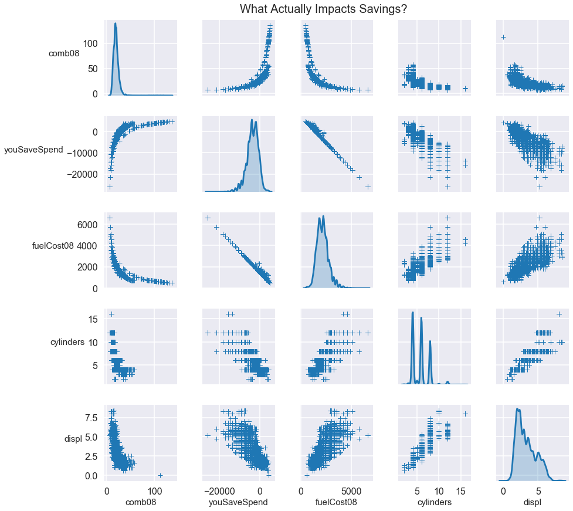

```python
v_df = vehicles_df[["comb08", "youSaveSpend", "fuelCost08", "cylinders", "displ"]]
g = sns.pairplot(v_df, diag_kind="kde", markers="+", palette="RdBu",
             plot_kws=dict(s=50, edgecolor="b", linewidth=1), diag_kws=dict(shade=True))
plt.subplots_adjust(top=.95)
g.fig.suptitle("What Actually Impacts Savings?",verticalalignment='top',fontsize=20)
for ax in g.axes.flat:
  plt.setp(ax.yaxis.get_label(), rotation=0,horizontalalignment='right',fontsize=15)
  plt.setp(ax.xaxis.get_label(),fontsize=15)
```

Something to note with the **youSaveSpend** field is that the more positive the number, the higher the savings. By looking at the **youSaveSpend** field in comparison to our other fields, we can quickly see a negative correlation with number of **cylinders**(engine cylinders), **displ**(engine displacement), and **fuelCost08**(annual fuel costs). To be specific, there is certainly a linear curve represented by annual fuel costs and savings. However, when we compare it to **comb08**(city + highway MPG), we see that these two fields actually have a positive relationship.

Usage of KDE in diagonal part of pair plot is a good idea.As we mentioned, name of attributes are not informative for audiences and even writers have used some descriptions in parenthesis.

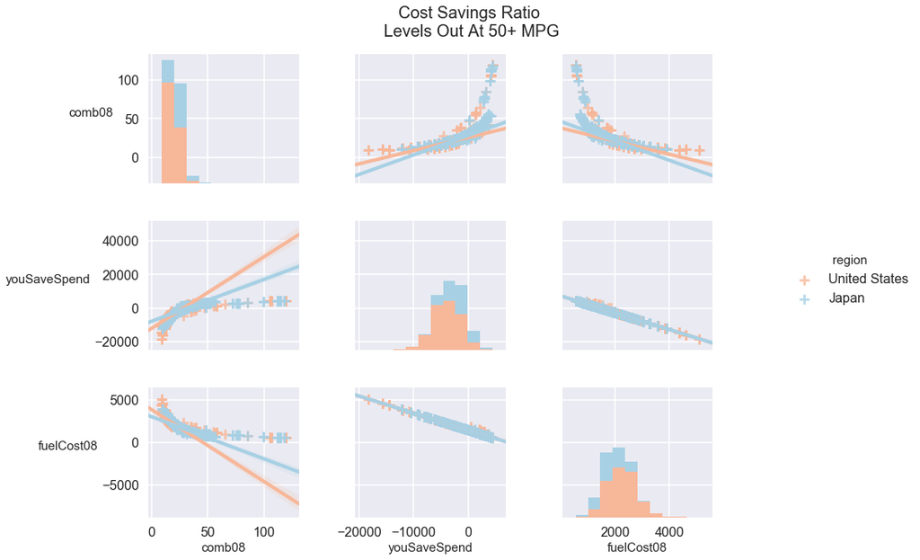

```python
g = sns.pairplot(vehicles_df, vars=["comb08", "youSaveSpend", "fuelCost08"],
             markers="+", palette="RdBu", kind='reg', hue="region")

g.fig.set_size_inches(15,10)
plt.subplots_adjust(top=.9)
g.fig.suptitle("Cost Savings Ratio \n Levels Out At 50+ MPG \n",verticalalignment='top',fontsize=20)

for ax in g.axes.flat:
  plt.setp(ax.yaxis.get_label(), rotation=0,horizontalalignment='right',fontsize=15)
  plt.setp(ax.xaxis.get_label(),fontsize=15)
```

A more detailed view of the **youSaveSpend** versus **combo08**(Combined MPG) shows that the cost savings ratio levels out around 50 MPG. This means that cars with fuel economy of greater than 50 MPG will have less of a cost efficiency boost than going from a car of 20 MPG to 30 MPG. Because the **FuelCost** is directly related to the **youSaveSpend** field it is clear that the less spent on fuel the more savings. Also noticing the **youSaveSpend** histogram it can quickly be seen that Japanese cars tend save the consumer more money over a five year span.

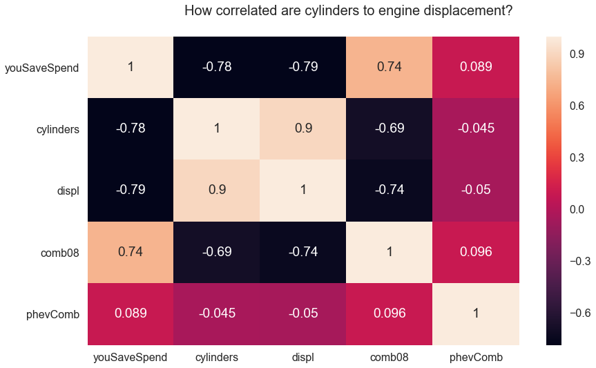

```python
v_corr = vehicles_df[["youSaveSpend", "cylinders", "displ", "comb08", "phevComb" ]]
plt.figure(figsize=(14,8))
sns.heatmap(v_corr.corr(),annot=True)
plt.subplots_adjust(top=.9)
plt.suptitle("How correlated are cylinders to engine displacement?",fontsize=20,verticalalignment='top')
plt.yticks(rotation=0)
plt.show()
```

Usage of a more suitable color palette could make a better insight for audiences. Based on values that could be between -1 and 1, we could use palettes same to following heatmap. Aditionally we could change name of some attributes and use more exhaustive title for this map.

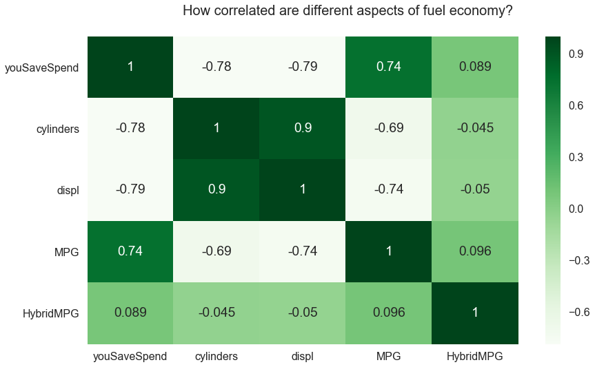

```python
#Ali's code
v_corr = vehicles_df[["youSaveSpend", "cylinders", "displ", "comb08", "phevComb" ]]
v_corr = v_corr.rename(columns={ "comb08" : "MPG", "phevComb": "HybridMPG" })
plt.figure(figsize=(14,8))
sns.heatmap(v_corr.corr(),cmap="Greens",annot=True)
plt.subplots_adjust(top=.9)
plt.suptitle("How correlated are different aspects of fuel economy?",fontsize=20,verticalalignment='top')
plt.yticks(rotation=0)
plt.show()
```